# Tumor Deconvolution methods

Dr.Parul Kulshreshtha

This notebook runs EPIC, MCPcounter for 2 individual methods and Decosus as the consensus method.

To address this assignment, we used the normalized gene expression matrix derived from the DESeq2 workflow performed in the earlier RNA-seq analysis. DESeq2 applies size-factor normalization to correct for differences in library depth across samples and models count data using a negative binomial framework, producing expression values that are comparable between samples. This normalization is conceptually similar to CPM or RPKM in that it adjusts for sequencing depth, but it is statistically more robust because it accounts for count dispersion and mean–variance relationships inherent to RNA-seq data. Therefore, instead of recalculating TPM or RPKM, we used the DESeq2-normalized expression matrix (linear scale for deconvolution methods and log/variance-stabilized form for GSVA), ensuring methodological consistency with the original analysis and appropriate input scaling for each downstream tool.

Q2Perform student t-test on the cellular estimates between tumour and normal groups for these estimates from the three methods above. List the cell types with the significant differences (p < 0.05), and produce boxplots for these significant ones.

```r
# Load Required Packages

library(DESeq2)
library(dplyr)
```

```r
library(ggplot2)
library(pheatmap)
library(gplots)
# Deconvolution methods
library(EPIC)
library(MCPcounter)
library(Decosus)

# GSVA & gene set analysis
library(GSVA)


# Parallel backend (serial for reproducibility)
library(BiocParallel)
register(SerialParam())
```

```r
# Load Raw Counts and Sample Data


rawCounts <- read.delim(
  "/Users/dr.parul/Downloads/data_required_for_CAN7032-7132/LAQ2_data/row_count_data.nodup.txt",
  header = TRUE,
  row.names = 1,
  check.names = FALSE
)  # Reads the raw RNA-seq count matrix (genes × samples)

sampleData <- read.delim(
  "/Users/dr.parul/Downloads/data_required_for_CAN7032-7132/LAQ2_data/sample_groups.txt",
  header = TRUE,
  row.names = 1
)  # Reads sample metadata (Patient ID and Group: Normal/Tumour)

# Ensure correct sample order
sampleData <- sampleData[colnames(rawCounts), ]
# Reorders metadata rows so they match the column order of the count matrix

# Convert variables to factors
sampleData$Patient <- factor(sampleData$Patient)
# Converts Patient column into a categorical variable

sampleData$Group <- factor(sampleData$Group)
# Converts Group (Tumour/Normal) into a categorical variable

sampleData$Group <- relevel(sampleData$Group, ref = "Normal")
# Sets "Normal" as the reference level for comparisons

# Create DESeq2 Object


dds <- DESeqDataSetFromMatrix(
  countData = rawCounts,
  colData   = sampleData,
  design    = ~ Patient + Group
)
# Creates DESeq2 dataset with paired design (controls for Patient effect)

# Filter low-count genes
keep <- rowSums(counts(dds) >= 10) >= 5
# Keeps genes that have at least 10 reads in at least 5 samples

dds <- dds[keep, ]
# Removes low-expression genes to improve statistical stability

# Run DESeq normalization
dds <- DESeq(dds)
# Estimates size factors, dispersion, and fits the negative binomial model
# This produces normalized counts internally and prepares the object for downstream analysis
```

We need to use 1. linear matrix for deconvolution 2. log/VST matrix for GSVA Saving both below:

```r
# Extract Normalized Linear Counts


norm_counts <- counts(dds, normalized = TRUE)
norm_counts_df <- data.frame(Gene = rownames(norm_counts),
                             norm_counts,
                             check.names = FALSE)

# Save linear normalized counts
write.table(norm_counts_df,
            "/Users/dr.parul/Downloads/data_required_for_CAN7032-7132/LAQ2_data/deseq_normalized_counts_linear.txt",
            sep = "\t",
            quote = FALSE,
            row.names = FALSE)


# Extract VST Matrix (for GSVA)


vst_obj <- vst(dds, blind = FALSE)
vst_mat <- assay(vst_obj)

vst_mat_df <- data.frame(Gene = rownames(vst_mat),
                         vst_mat,
                         check.names = FALSE)

# Save VST matrix
write.table(vst_mat_df,
            "/Users/dr.parul/Downloads/data_required_for_CAN7032-7132/LAQ2_data/deseq_vst_matrix.txt",
            sep = "\t",
            quote = FALSE,
            row.names = FALSE)

cat("Normalized linear matrix and VST matrix saved successfully.\n")
```

```
## Normalized linear matrix and VST matrix saved successfully.
```

```r
#checking number of genes in the data

cat("Number of genes in normalized linear matrix:",
    nrow(norm_counts), "\n")
```

```
## Number of genes in normalized linear matrix: 12403
```

```r
cat("Number of genes in VST matrix:",
    nrow(vst_mat), "\n")
```

```
## Number of genes in VST matrix: 12403
```

```r
cat("Number of samples:",
    ncol(norm_counts), "\n")
```

```
## Number of samples: 10
```

Normalization changes the scale and variance structure Different normalizations do different things: TPM normalizes for library size and gene length. DESeq2 size-factor normalization corrects for library size but keeps counts in a count-based framework. VST/rlog additionally stabilizes variance across expression ranges.

DESeq2 normalization is safer for this assignment: DESeq2 normalization: Models count dispersion, Handles mean–variance dependence, Produces more statistically stable inputs for downstream testing. TPM: Is purely scaling-based, Does not account for dispersion, May distort variance structure for GSVA comparisons.

```r
norm_mat <- as.matrix(norm_counts)
epic_out <- EPIC(bulk = norm_mat)

est_EPIC_mRNAProp <- t(epic_out$mRNAProportions)
est_EPIC_cellProp <- t(epic_out$cellFractions)

colSums(est_EPIC_mRNAProp)
```

```
## S02_Normal S03_Normal S05_Normal S06_Normal S10_Normal S02_Tumour S03_Tumour
##          1          1          1          1          1          1          1
## S05_Tumour S06_Tumour S10_Tumour
##          1          1          1
```

```r
colSums(est_EPIC_cellProp)
```

```
## S02_Normal S03_Normal S05_Normal S06_Normal S10_Normal S02_Tumour S03_Tumour
##          1          1          1          1          1          1          1
## S05_Tumour S06_Tumour S10_Tumour
##          1          1          1
```

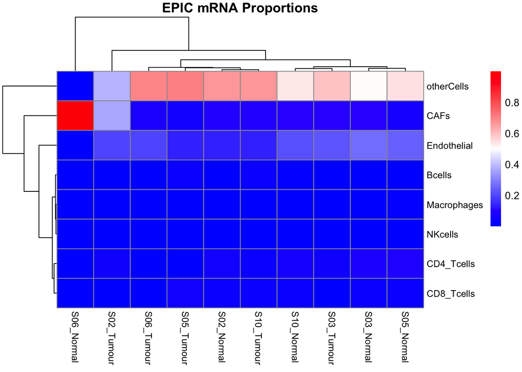

```r
# Helper function to save pheatmap without re-rendering
save_pheatmap <- function(x, filepath) {
  png(filepath, width = 1200, height = 900)
  grid::grid.newpage()
  grid::grid.draw(x$gtable)
  dev.off()
}

# Render in knit AND save separately
p1 <- pheatmap(est_EPIC_mRNAProp,
               color = colorRampPalette(c("blue", "white", "red"))(100),
               scale = "none", cluster_rows = TRUE, cluster_cols = TRUE,
               main = "EPIC mRNA Proportions",
               fontsize_col = 9, fontsize_row = 9)
```

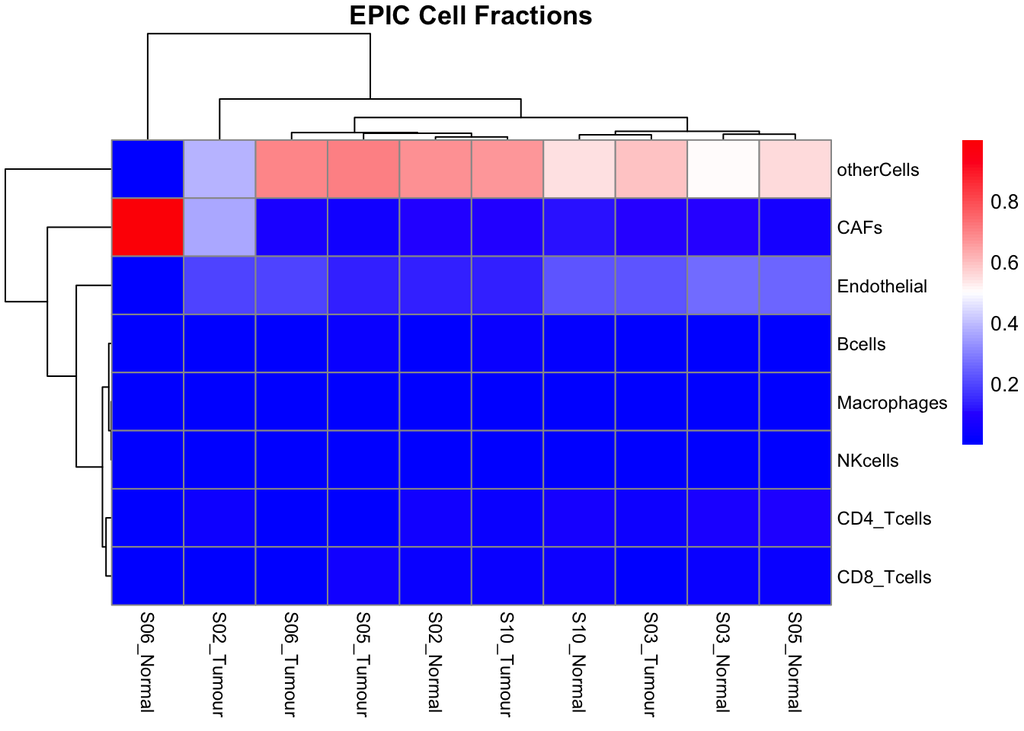

```r
p2 <- pheatmap(est_EPIC_cellProp,
               color = colorRampPalette(c("blue", "white", "red"))(100),
               scale = "none", cluster_rows = TRUE, cluster_cols = TRUE,
               main = "EPIC Cell Fractions",
               fontsize_col = 9, fontsize_row = 9)
```

```r
save_pheatmap(p1, "/Users/dr.parul/Downloads/data_required_for_CAN7032-7132/LAQ2_data/EPIC_mRNAProportions_2025-02-25.png")
```

```r
save_pheatmap(p2, "/Users/dr.parul/Downloads/data_required_for_CAN7032-7132/LAQ2_data/EPIC_cellFractions_2025-02-25.png")
```

```r
cat("EPIC heatmaps saved successfully.\n")
```

```
## EPIC heatmaps saved successfully.
```

```r
est_EPIC_cellProp
```

```
##               S02_Normal   S03_Normal   S05_Normal   S06_Normal   S10_Normal
## Bcells      1.137165e-03 4.381454e-03 1.000067e-02 3.879726e-06 2.059762e-02
## CAFs        9.833110e-02 1.062500e-01 6.153233e-02 9.998532e-01 1.100748e-01
## CD4_Tcells  5.460846e-02 7.465288e-02 8.283862e-02 9.614951e-07 6.266662e-02
## CD8_Tcells  3.615122e-02 3.268413e-02 3.385009e-02 7.186921e-09 4.011587e-02
## Endothelial 1.340629e-01 2.683313e-01 2.523762e-01 1.236296e-05 2.214252e-01
## Macrophages 2.901023e-03 4.187683e-03 6.227283e-03 2.712916e-06 3.081669e-03
## NKcells     3.922007e-09 3.607293e-08 1.240696e-08 1.268551e-04 1.566788e-08
## otherCells  6.728082e-01 5.095126e-01 5.531748e-01 4.403320e-10 5.420382e-01
##               S02_Tumour   S03_Tumour   S05_Tumour   S06_Tumour   S10_Tumour
## Bcells      3.631597e-03 7.830548e-03 0.0307520899 1.031628e-02 3.043507e-02
## CAFs        3.693796e-01 1.066155e-01 0.0538425760 7.919238e-02 9.577289e-02
## CD4_Tcells  4.297281e-02 4.715718e-02 0.0167675813 5.423851e-03 3.752145e-02
## CD8_Tcells  5.152317e-06 1.838821e-02 0.0565899463 1.902714e-02 3.201902e-02
## Endothelial 1.954228e-01 2.268905e-01 0.1346898486 1.912527e-01 1.346966e-01
## Macrophages 4.161355e-03 1.034959e-03 0.0016720017 4.829663e-05 9.868853e-04
## NKcells     7.267669e-07 1.994785e-07 0.0009323928 4.219037e-08 1.901911e-08
## otherCells  3.844259e-01 5.920829e-01 0.7047535633 6.947393e-01 6.685681e-01
```

This is a matrix of: Estimated cell-type proportions per sample Values range from 0 to 1 Columns = samples Rows = cell types Each column sums to ~1 These are the final inferred cellular composition fractions.

EPIC Results Summary:

Cell Fractions heatmap: Same pattern — otherCells highest across most samples, S06_Normal extreme outlier for CAFs (red), S02_Tumour also elevated CAFs. Endothelial cells moderately present. Immune infiltration minimal throughout.

Numeric table confirms:

CAFs: S06_Normal ~99.9%, all others much lower (~5–36%)

Endothelial: ~13–27% in most samples, near zero in S06_Normal

All immune cell types (Bcells, CD4, CD8, NK, Macrophages): very low, mostly <5%

```r
# Running paired Student t-tests (Tumour vs Normal, matched by patient)
epic_df <- as.data.frame(est_EPIC_cellProp)

# Extracting patient ID and group from sample names
sample_names <- colnames(epic_df)
group <- ifelse(grepl("Tumour", sample_names), "Tumour", "Normal")
patient <- gsub("_(Tumour|Normal)", "", sample_names)

# Initialising results storage
t_test_results <- data.frame(
  Cell_Type = rownames(epic_df),
  Mean_Normal = NA,
  Mean_Tumour = NA,
  P_value = NA
)

# Looping through each cell type
for (i in 1:nrow(epic_df)) {

  values <- as.numeric(epic_df[i, ])

  # Building a data frame to ensuring patient-matched ordering
  df_temp <- data.frame(value = values, group = group, patient = patient)

  # Ordering normal and tumour values by patient ID
  normal_ordered <- df_temp[df_temp$group == "Normal", ]
  tumour_ordered <- df_temp[df_temp$group == "Tumour", ]
  normal_ordered <- normal_ordered[order(normal_ordered$patient), ]
  tumour_ordered <- tumour_ordered[order(tumour_ordered$patient), ]

  # Performing paired t-test
  test <- t.test(tumour_ordered$value, normal_ordered$value, paired = TRUE)

  # Storing mean values and p-value
  t_test_results$Mean_Normal[i] <- mean(normal_ordered$value)
  t_test_results$Mean_Tumour[i] <- mean(tumour_ordered$value)
  t_test_results$P_value[i] <- test$p.value
}

# Identifying significant cell types (p < 0.05)
significant_cells <- t_test_results[t_test_results$P_value < 0.05, ]
t_test_results
```

| Cell_Type | Mean_Normal | Mean_Tumour | P_value |
| --- | --- | --- | --- |
| Bcells | 7.224158e-03 | 0.016593116 | 0.04541982 |
| CAFs | 2.752083e-01 | 0.140960593 | 0.54618723 |
| CD4_Tcells | 5.495351e-02 | 0.029968574 | 0.10218415 |
| CD8_Tcells | 2.856026e-02 | 0.025205892 | 0.77469077 |
| Endothelial | 1.752416e-01 | 0.176590505 | 0.98203594 |
| Macrophages | 3.280074e-03 | 0.001580699 | 0.18227589 |
| NKcells | 2.538463e-05 | 0.000186676 | 0.45322513 |
| otherCells | 4.555067e-01 | 0.608913944 | 0.38426541 |

```r
significant_cells
```

|  | Cell_Type | Mean_Normal | Mean_Tumour | P_value |
| --- | --- | --- | --- | --- |
| 1 | Bcells | 0.007224158 | 0.01659312 | 0.04541982 |

only Bcells shows a significant difference between tumour and normal in EPIC cell fractions.

```r
# Ensuring matrix format
norm_mat <- as.matrix(norm_counts)

# Running MCP-counter
est_MCPcounter <- MCPcounter.estimate(
  norm_mat,
  featuresType = "HUGO_symbols"
)

# Checking dimensions
dim(est_MCPcounter)
```

```
## [1]  9 10
```

```r
# Splitting into Normal and Tumour tables
mcp_df <- as.data.frame(est_MCPcounter)
mcp_df <- cbind(Cell_Type = rownames(mcp_df), mcp_df)
rownames(mcp_df) <- NULL

# Normal samples only
normal_cols <- c("Cell_Type", colnames(mcp_df)[grepl("Normal", colnames(mcp_df))])
mcp_normal <- mcp_df[, normal_cols]
cat("Normal Samples:\n")
```

```
## Normal Samples:
```

```r
mcp_normal
```

| Cell_Type | S02_Normal | S03_Normal | S05_Normal | S06_Normal | S10_Normal |
| --- | --- | --- | --- | --- | --- |
| T cells | 52.832942 | 74.28665 | 63.84339 | 57.15523 | 129.11276 |
| CD8 T cells | 41.055735 | 47.22860 | 53.73429 | 133.38723 | 93.74663 |
| Cytotoxic lymphocytes | 32.568252 | 66.90718 | 72.66341 | 35.59997 | 45.92318 |
| B lineage | 3.158133 | 10.16727 | 11.66957 | 17.42446 | 72.52696 |
| Monocytic lineage | 159.260161 | 179.07510 | 264.36805 | 151.41253 | 162.60879 |
| Myeloid dendritic cells | 80.729788 | 135.78222 | 66.35371 | 120.99483 | 201.74529 |
| Neutrophils | 736.860220 | 250.19912 | 288.44381 | 383.03765 | 327.02735 |
| Endothelial cells | 155.044616 | 204.00131 | 170.56566 | 282.54660 | 189.73664 |
| Fibroblasts | 1870.517355 | 1763.76326 | 1081.31534 | 31556.89489 | 1797.20262 |

```r
# Tumour samples only
tumour_cols <- c("Cell_Type", colnames(mcp_df)[grepl("Tumour", colnames(mcp_df))])
mcp_tumour <- mcp_df[, tumour_cols]
cat("Tumour Samples:\n")
```

```
## Tumour Samples:
```

```r
mcp_tumour
```

| Cell_Type | S02_Tumour | S03_Tumour | S05_Tumour | S06_Tumour | S10_Tumour |
| --- | --- | --- | --- | --- | --- |
| T cells | 109.91096 | 134.58652 | 152.04980 | 119.88926 | 103.99614 |
| CD8 T cells | 74.74877 | 76.51792 | 158.69432 | 37.81996 | 99.63702 |
| Cytotoxic lymphocytes | 67.93755 | 27.80151 | 62.70361 | 0.00000 | 81.57781 |
| B lineage | 24.91626 | 52.20222 | 133.01938 | 43.11475 | 161.07986 |
| Monocytic lineage | 214.96508 | 166.88194 | 177.38375 | 202.93108 | 89.49540 |
| Myeloid dendritic cells | 59.20522 | 81.36405 | 73.34774 | 15.12798 | 64.45270 |
| Neutrophils | 229.03661 | 135.40028 | 270.16740 | 259.98519 | 290.01491 |
| Endothelial cells | 182.50575 | 211.44451 | 121.95594 | 194.39458 | 151.01236 |
| Fibroblasts | 4970.04462 | 1517.96975 | 851.64106 | 1178.46986 | 1498.11382 |

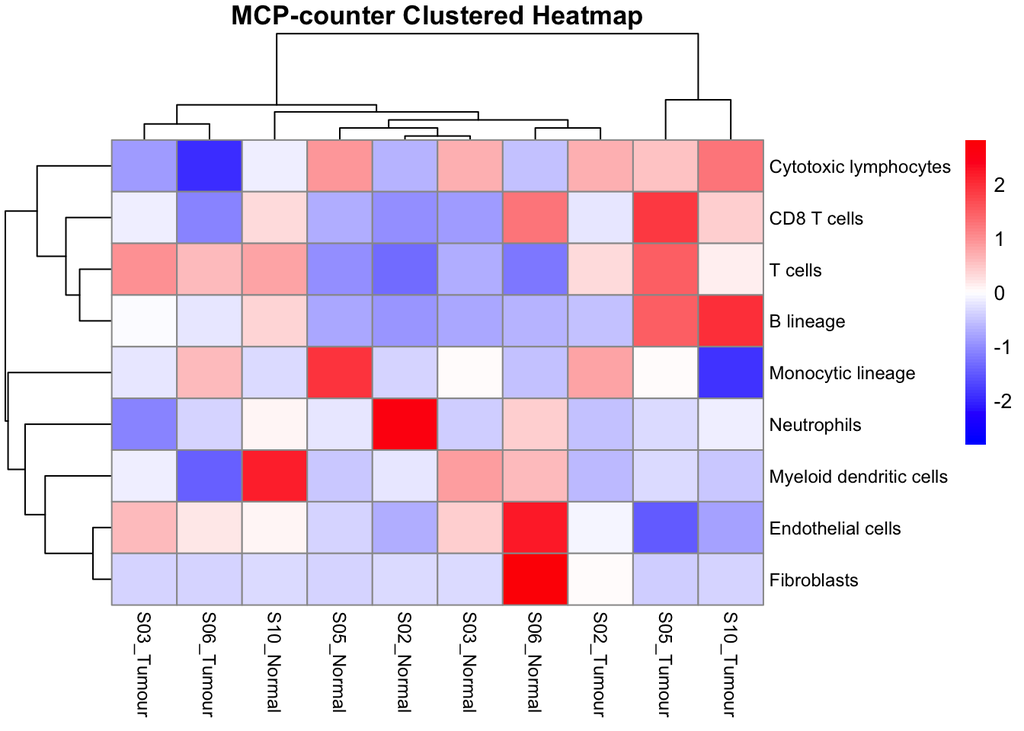

```r
# Clustering columns (samples) by Spearman correlation
hc <- hclust(
  as.dist(1 - cor(est_MCPcounter, method = "spearman")),
  method = "ward.D"
)

# Clustering rows (cell types) by Pearson correlation
hr <- hclust(
  as.dist(1 - cor(t(est_MCPcounter), method = "pearson")),
  method = "average"
)

# Rendering and saving MCP-counter heatmap
p_mcp <- pheatmap(
  as.matrix(est_MCPcounter),
  cluster_rows = hr,
  cluster_cols = hc,
  color = colorRampPalette(c("blue", "white", "red"))(100),
  scale = "row",
  main = "MCP-counter Clustered Heatmap",
  fontsize_col = 9,
  fontsize_row = 9
)
```

```r
save_pheatmap(p_mcp, "/Users/dr.parul/Downloads/data_required_for_CAN7032-7132/LAQ2_data/MCPcounter_Heatmap_2025-02-25.png")
```

```r
cat("MCP-counter heatmap saved successfully.\n")
```

```
## MCP-counter heatmap saved successfully.
```

```r
# Building paired comparison table (Normal vs Tumour per patient)
mcp_mat <- as.data.frame(est_MCPcounter)

# Creating paired table per patient
patients <- c("S02", "S03", "S05", "S06", "S10")

paired_list <- lapply(patients, function(p) {
  normal_col <- paste0(p, "_Normal")
  tumour_col <- paste0(p, "_Tumour")
  data.frame(
    Cell_Type = rownames(mcp_mat),
    Patient = p,
    Normal = mcp_mat[[normal_col]],
    Tumour = mcp_mat[[tumour_col]],
    Difference = mcp_mat[[tumour_col]] - mcp_mat[[normal_col]]
  )
})

paired_mcp <- do.call(rbind, paired_list)
rownames(paired_mcp) <- NULL
paired_mcp
```

| Cell_Type | Patient | Normal | Tumour | Difference |
| --- | --- | --- | --- | --- |
| T cells | S02 | 52.832942 | 109.91096 | 57.078020 |
| CD8 T cells | S02 | 41.055735 | 74.74877 | 33.693033 |
| Cytotoxic lymphocytes | S02 | 32.568252 | 67.93755 | 35.369297 |
| B lineage | S02 | 3.158133 | 24.91626 | 21.758123 |
| Monocytic lineage | S02 | 159.260161 | 214.96508 | 55.704923 |
| Myeloid dendritic cells | S02 | 80.729788 | 59.20522 | -21.524571 |
| Neutrophils | S02 | 736.860220 | 229.03661 | -507.823606 |
| Endothelial cells | S02 | 155.044616 | 182.50575 | 27.461138 |
| Fibroblasts | S02 | 1870.517355 | 4970.04462 | 3099.527266 |
| T cells | S03 | 74.286650 | 134.58652 | 60.299866 |

[output cut: 35 more lines]

Table observations:

Key difference from EPIC: MCP-counter gives absolute enrichment scores (not proportions), so values are not constrained to sum to 1. This explains the large numeric range. The S06_Normal Fibroblasts outlier is consistent across both methods, strengthening confidence in that finding.

```r
# Converting MCP matrix to numeric data frame
mcp_df <- as.data.frame(est_MCPcounter)

# Extracting group and patient ID from column names
sample_names <- colnames(mcp_df)
group <- ifelse(grepl("Tumour", sample_names), "Tumour", "Normal")
patient <- gsub("_(Tumour|Normal)", "", sample_names)

# Initialising results storage
mcp_ttest_results <- data.frame(
  Cell_Type = rownames(mcp_df),
  Mean_Normal = NA,
  Mean_Tumour = NA,
  P_value = NA
)

# Looping through each cell type
for (i in 1:nrow(mcp_df)) {

  values <- as.numeric(mcp_df[i, ])

  # Building data frame for patient-matched ordering
  df_temp <- data.frame(value = values, group = group, patient = patient)

  # Ordering normal and tumour values by patient ID
  normal_ordered <- df_temp[df_temp$group == "Normal", ]
  tumour_ordered <- df_temp[df_temp$group == "Tumour", ]
  normal_ordered <- normal_ordered[order(normal_ordered$patient), ]
  tumour_ordered <- tumour_ordered[order(tumour_ordered$patient), ]

  # Performing paired t-test
  test <- t.test(tumour_ordered$value, normal_ordered$value, paired = TRUE)

  # Storing mean values and p-value
  mcp_ttest_results$Mean_Normal[i] <- mean(normal_ordered$value)
  mcp_ttest_results$Mean_Tumour[i] <- mean(tumour_ordered$value)
  mcp_ttest_results$P_value[i] <- test$p.value
}

# Viewing all results
mcp_ttest_results
```

| Cell_Type | Mean_Normal | Mean_Tumour | P_value |
| --- | --- | --- | --- |
| T cells | 75.44619 | 124.08654 | 0.06488821 |
| CD8 T cells | 73.83050 | 89.48360 | 0.65394196 |
| Cytotoxic lymphocytes | 50.73240 | 48.00410 | 0.87596280 |
| B lineage | 22.98928 | 82.86649 | 0.03680390 |
| Monocytic lineage | 183.34493 | 170.33145 | 0.68658284 |
| Myeloid dendritic cells | 121.12117 | 58.69954 | 0.07806601 |
| Neutrophils | 397.11363 | 236.92088 | 0.14739223 |
| Endothelial cells | 200.37897 | 172.26263 | 0.24409347 |
| Fibroblasts | 7613.93869 | 2003.24782 | 0.41845128 |

```r
# Identifying significant cell types (p < 0.05)
mcp_significant <- mcp_ttest_results[mcp_ttest_results$P_value < 0.05, ]
mcp_significant
```

|  | Cell_Type | Mean_Normal | Mean_Tumour | P_value |
| --- | --- | --- | --- | --- |
| 4 | B lineage | 22.98928 | 82.86649 | 0.0368039 |

MCP-counter paired t-test results: Only B lineage is significant (p = 0.037) — Mean Normal = 22.99, Mean Tumour = 82.87, meaning B lineage is notably higher in tumour samples.

MCPcounter & EPIC — both methods independently flag B cells as the only significantly different immune cell type between tumour and normal. That convergence strengthens the finding. Ready to continue.

```r
# Checking gene name format in normalized counts
head(rownames(norm_counts), 20)
```

```
##  [1] "CHAC1"   "GLRX"    "MEFV"    "STXBP1"  "AKAP8L"  "AKR1C1"  "CTSL"
##  [8] "IGFBP4"  "COQ8A"   "CD4"     "FDFT1"   "MAPK1"   "STIP1"   "AGRN"
## [15] "ABCG1"   "COPS3"   "PFDN2"   "TSC22D3" "BCL2L2"  "ERBB3"
```

```r
# Prepare DESeq2 normalized data for Decosus


# Convert normalized counts to data frame
norm_df_decosus <- as.data.frame(norm_counts)

# Add hgnc_symbols column (required by Decosus)
norm_df_decosus$hgnc_symbols <- rownames(norm_df_decosus)

# Run Decosus consensus deconvolution


est_Decosus <- Decosus::cosDeco(
  x = norm_df_decosus,
  rnaseq = TRUE,
  plot = TRUE
)
```

```
## [1] "Num. of genes: 7849"
```

```
## ℹ GSVA version 2.4.4
```

```
## ℹ Searching for rows with constant values
```

```
## ! Some gene sets have size one. Consider setting minSize > 1
```

```
## ℹ Calculating ssGSEA scores for 486 gene sets
```

```
## ℹ Calculating ranks
```

```
## ℹ Calculating rank weights
```

```
## ✔ Calculations finished
```

```
##
## Setting helper functions for quanTIseq
```

```
##
## Running quanTIseq deconvolution module
```

```
## Gene expression normalization and re-annotation (arrays: FALSE)
```

```
## Removing 17 noisy genes
```

```
## Signature genes found in data set: 104/153 (67.97%)
```

```
## Mixture deconvolution (method: lsei)
```

```r
# Extract Results


# Sample-level scores
est_Decosus_samples <- est_Decosus$main_samples

# Cell-type-level scores
est_Decosus_cells <- est_Decosus$main_cells

# Check dimensions
dim(est_Decosus_samples)
```

```
## [1] 80 10
```

```r
dim(est_Decosus_cells)
```

```
## [1] 15 10
```

```r
# Preview
head(est_Decosus_samples)
```

|  | S02_Normal | S03_Normal | S05_Normal | S06_Normal | S10_Normal | S02_Tumour | S03_Tumour | S05_Tumour | S06_Tumour | S10_Tumour |
| --- | --- | --- | --- | --- | --- | --- | --- | --- | --- | --- |
| B cell_consensus | 0.5176098 | 0.2194236 | 0.5829068 | 0.4196632 | 0.7800533 | 0.4513624 | 0.5503248 | 1.41536835 | 0.6909655 | 1.7296703 |
| Cancer associated fibroblast_consensus | 0.4163994 | 0.1563466 | 0.3073388 | 2.8253430 | 0.1726550 | 0.5764759 | 0.1443269 | 0.07552676 | 0.1087850 | 0.1338240 |
| cytotoxicity score_consensus | 0.6907439 | 1.0260968 | 1.0736352 | 0.7220515 | 0.9356024 | 1.1525859 | 0.5576894 | 1.01961531 | 0.2266804 | 1.4248281 |
| Endothelial cell_consensus | 0.4793397 | 0.7841625 | 1.0318378 | 1.4066230 | 0.6790938 | 0.6227678 | 0.7288693 | 0.42606519 | 0.6439271 | 0.4775924 |
| Macrophage_consensus | 0.7381931 | 1.1080778 | 1.6261732 | 0.7419072 | 0.7835918 | 1.1087027 | 0.4437975 | 0.61069607 | 0.3831028 | 0.4165417 |
| Macrophage M1_consensus | 1.1791018 | 0.3723611 | 1.1504008 | 1.3388431 | 0.4525520 | 0.5472173 | 0.2564812 | 0.44434915 | 0.5446700 | 0.2724281 |

```r
head(est_Decosus_cells)
```

|  | S02_Normal | S03_Normal | S05_Normal | S06_Normal | S10_Normal | S02_Tumour | S03_Tumour | S05_Tumour | S06_Tumour | S10_Tumour |
| --- | --- | --- | --- | --- | --- | --- | --- | --- | --- | --- |
| B cell_consensus | 0.4150400 | 1.289486e-01 | 0.6457156 | 0.4540715 | 1.0250897 | 0.4243733 | 0.5510284 | 1.474986 | 0.8830012 | 1.7532148 |
| Monocyte_consensus | NaN | NaN | NaN | NaN | NaN | NaN | NaN | NaN | NaN | NaN |
| Neutrophil_consensus | 0.5349197 | 1.802626e+00 | 1.5297952 | 0.2411260 | 1.1884240 | 0.5972711 | 0.7604174 | 0.608778 | 0.5441185 | 0.2280149 |
| NK cell_consensus | 0.7921439 | 5.750306e-05 | 0.2271246 | 0.9029261 | 0.2342540 | 0.7230768 | 0.1008543 | 1.733915 | 0.4472371 | 0.4822545 |
| T cell CD8+_consensus | 0.5689587 | 4.888446e-01 | 0.5062835 | 1.0206951 | 1.0517331 | 0.5481304 | 0.5078513 | 1.429725 | 0.2845819 | 1.0343021 |
| uncharacterized cell_consensus | 1.1973355 | 4.248069e-01 | 0.4612103 | 0.4799026 | 0.6871065 | 0.8993523 | 1.0030584 | 1.020555 | 1.0288866 | 1.3158473 |

Decosus ran successfully:

7849 genes used, 80 samples-level scores × 10 samples, 15 cell types × 10 samples 104/153 signature genes found (67.97%) — acceptable coverage Used ssGSEA and quanTIseq internally — confirming it is a consensus method

Results summary:

Cancer associated fibroblasts — S06_Normal extreme outlier again (2.83) vs all others (<0.6), fully consistent with EPIC CAFs and MCP-counter Fibroblasts findings B cell consensus — S05_Tumour (1.42) and S10_Tumour (1.73) notably elevated, again consistent with EPIC and MCP-counter B cell findings

Cytotoxicity score — slightly higher in some tumour samples (S02, S05 Tumour), suggesting modest immune activation

Endothelial cells — S06_Normal elevated (1.41), drops in tumour Macrophage and Macrophage M1 — variable across samples, no clear tumour/normal pattern Macrophage — S05_Normal highest (1.63)

Cross-method consistency: All three methods (EPIC, MCP-counter, Decosus) agree on S06_Normal fibroblast/CAF dominance and B cell elevation in tumour.

```r
# Converting Decosus output to numeric matrix
est_Decosus_samples_mat <- as.matrix(est_Decosus_samples)
est_Decosus_samples_mat <- apply(est_Decosus_samples_mat, 2, as.numeric)
rownames(est_Decosus_samples_mat) <- rownames(est_Decosus_samples)

# Identifying fully NaN rows
nan_rows <- apply(est_Decosus_samples_mat, 1, function(x) all(is.nan(x)))
rownames(est_Decosus_samples_mat)[nan_rows]
```

```
## [1] "Monocyte_consensus"
```

```r
# Removing fully NaN rows and replacing remaining NaN with 0
est_Decosus_clean <- est_Decosus_samples_mat[!nan_rows, ]
est_Decosus_clean[is.nan(est_Decosus_clean)] <- 0

# Checking cleaned dimensions
dim(est_Decosus_clean)
```

```
## [1] 79 10
```

```r
head(est_Decosus_clean)
```

```
##                                        S02_Normal S03_Normal S05_Normal
## B cell_consensus                        0.5176098  0.2194236  0.5829068
## Cancer associated fibroblast_consensus  0.4163994  0.1563466  0.3073388
## cytotoxicity score_consensus            0.6907439  1.0260968  1.0736352
## Endothelial cell_consensus              0.4793397  0.7841625  1.0318378
## Macrophage_consensus                    0.7381931  1.1080778  1.6261732
## Macrophage M1_consensus                 1.1791018  0.3723611  1.1504008
##                                        S06_Normal S10_Normal S02_Tumour
## B cell_consensus                        0.4196632  0.7800533  0.4513624
## Cancer associated fibroblast_consensus  2.8253430  0.1726550  0.5764759
## cytotoxicity score_consensus            0.7220515  0.9356024  1.1525859
## Endothelial cell_consensus              1.4066230  0.6790938  0.6227678
## Macrophage_consensus                    0.7419072  0.7835918  1.1087027
## Macrophage M1_consensus                 1.3388431  0.4525520  0.5472173
##                                        S03_Tumour S05_Tumour S06_Tumour
## B cell_consensus                        0.5503248 1.41536835  0.6909655
## Cancer associated fibroblast_consensus  0.1443269 0.07552676  0.1087850
## cytotoxicity score_consensus            0.5576894 1.01961531  0.2266804
## Endothelial cell_consensus              0.7288693 0.42606519  0.6439271
## Macrophage_consensus                    0.4437975 0.61069607  0.3831028
## Macrophage M1_consensus                 0.2564812 0.44434915  0.5446700
##                                        S10_Tumour
## B cell_consensus                        1.7296703
## Cancer associated fibroblast_consensus  0.1338240
## cytotoxicity score_consensus            1.4248281
## Endothelial cell_consensus              0.4775924
## Macrophage_consensus                    0.4165417
## Macrophage M1_consensus                 0.2724281
```

Monocyte_consensus was the only fully NaN row — removed Cleaned matrix: 79 cell types × 10 samples Data looks clean, no remaining NaN issues

Monocyte_consensus being NaN is not unusual — Decosus could not reliably estimate monocyte scores from this dataset, possibly due to insufficient signature gene coverage for that specific cell type.

```r
# Checking convergence details for S06_Normal
est_Decosus$fit.gof
```

[output not shown]

```r
# Checking dimensions of cleaned estimates (cell types x samples)
cat("Dimensions of clean estimates (cell types x samples):\n")
```

```
## Dimensions of clean estimates (cell types x samples):
```

```r
dim(est_Decosus_clean)
```

```
## [1] 79 10
```

```r
# Checking for any remaining NaN values
cat("\nAny NaN values remaining:\n")
```

```
##
## Any NaN values remaining:
```

```r
sum(is.nan(as.matrix(est_Decosus_clean)))
```

```
## [1] 0
```

```r
# Checking for any remaining NA values
cat("\nAny NA values remaining:\n")
```

```
##
## Any NA values remaining:
```

```r
sum(is.na(as.matrix(est_Decosus_clean)))
```

```
## [1] 0
```

```r
# Checking value ranges
cat("\nMin value:\n")
```

```
##
## Min value:
```

```r
min(est_Decosus_clean, na.rm = TRUE)
```

```
## [1] 0
```

```r
cat("\nMax value:\n")
```

```
##
## Max value:
```

```r
max(est_Decosus_clean, na.rm = TRUE)
```

```
## [1] 3
```

```r
# Checking column sums per sample
cat("\nColumn sums per sample:\n")
```

```
##
## Column sums per sample:
```

```r
colSums(est_Decosus_clean, na.rm = TRUE)
```

```
## S02_Normal S03_Normal S05_Normal S06_Normal S10_Normal S02_Tumour S03_Tumour
##   42.01253   37.20589   47.17014   57.42379   57.88788   40.93572   57.34433
## S05_Tumour S06_Tumour S10_Tumour
##   61.70977   47.11325   51.24757
```

```r
# Previewing the full clean estimates matrix
cat("\nFull clean estimates:\n")
```

```
##
## Full clean estimates:
```

```r
print(round(est_Decosus_clean, 4))
```

```
##                                        S02_Normal S03_Normal S05_Normal
## B cell_consensus                           0.5176     0.2194     0.5829
## Cancer associated fibroblast_consensus     0.4164     0.1563     0.3073
## cytotoxicity score_consensus               0.6907     1.0261     1.0736
## Endothelial cell_consensus                 0.4793     0.7842     1.0318
## Macrophage_consensus                       0.7382     1.1081     1.6262
## Macrophage M1_consensus                    1.1791     0.3724     1.1504
## Macrophage M2_consensus                    0.9682     0.8509     1.4044
## Mast cell_consensus                        0.6342     0.7517     0.6008
## Myeloid dendritic cell_consensus           0.3904     0.8324     0.6462
## Neutrophil_consensus                       0.7806     1.4576     0.8717
## NK cell_consensus                          0.4906     0.4779     0.6979
## Plasmacytoid dendritic cell_consensus      0.5726     0.4686     0.9436
## T cell CD4+ (non-regulatory)_consensus     1.4833     0.0000     0.0000
## T cell CD4+ memory_consensus               0.2792     0.2774     0.6158
## T cell CD4+ Th1_consensus                  0.0000     0.0000     1.7466
## T cell CD4+ Th2_consensus                  0.0000     0.0000     0.0000
## T cell CD8+_consensus                      0.3785     0.4792     0.6042
## T cell CD8+ effector memory_consensus      0.2923     0.4777     0.2873
## T cell regulatory (Tregs)_consensus        0.2663     0.2150     0.3210
## uncharacterized cell_consensus             1.1973     0.4248     0.4612
## aDC_xcell                                  2.7038     1.1579     0.0000
## Adipocytes_xcell                           0.0000     1.9506     1.6891
## Astrocytes_xcell                           0.5129     0.0000     0.0000
## Basophils_xcell                            0.0000     1.3902     0.0000
## CD4_Tcells_EPIC                            1.0334     1.4127     1.5676
## CD4+ naive T-cells_xcell                   0.8842     0.0000     0.0493
## CD4+ Tcm_xcell                             0.0000     0.0000     2.4870
## CD4+ Tem_xcell                             0.0000     0.0000     0.2122
## CD8 effector-NK-cells_Davoli               0.7942     0.7652     0.7874
## CD8+ naive T-cells_xcell                   0.0000     0.0000     0.8869
## CD8+ Tcm_xcell                             0.0000     0.0000     0.0000
## cDC_xcell                                  0.6288     1.1298     0.9001
## Chondrocytes_xcell                         0.9917     0.6366     0.3028
## Class-switched memory B-cells_xcell        0.0000     0.0000     0.2438
## CLP_xcell                                  2.6206     0.1925     0.8063
## CMP_xcell                                  1.3017     1.0509     0.0000
## Co-inhibition, APC_Rooney                  0.7184     0.8391     1.0307
## Co-inhibition, T cell_Rooney               0.2829     0.3219     0.6208
## Co-stimulation, APC_Rooney                 1.3041     1.0291     0.7366
```

[output cut: 265 more lines]

```
## NK CD56dim cells_Danaher                   0.8050
## NKT_xcell                                  0.0000
## Osteoblast_xcell                           0.1846
## Pericytes_xcell                            0.0000
## Plasma cells_xcell                         2.2215
## Platelets_xcell                            1.2939
## Preadipocytes_xcell                        0.2759
## pro B-cells_xcell                          2.6016
## Sebocytes_xcell                            0.0000
## Skeletal muscle_xcell                      0.6825
## Smooth muscle_xcell                        1.3099
## StromaScore_xcell                          0.0000
## T cells_MCP                                0.9372
## T-cells_Danaher                            1.0486
## Tgd cells_xcell                            0.0000
```

Data is clean, ready for heatmap and paired t-test.

```r
# Converting Decosus clean matrix to data frame
decosus_df <- as.data.frame(est_Decosus_clean)

# Extracting group and patient ID from column names
sample_names <- colnames(decosus_df)
group <- ifelse(grepl("Tumour", sample_names), "Tumour", "Normal")
patient <- gsub("_(Tumour|Normal)", "", sample_names)

# Initialising results storage
decosus_ttest_results <- data.frame(
  Cell_Type = rownames(decosus_df),
  Mean_Normal = NA,
  Mean_Tumour = NA,
  P_value = NA
)

# Looping through each cell type
for (i in 1:nrow(decosus_df)) {

  values <- as.numeric(decosus_df[i, ])

  # Building data frame for patient-matched ordering
  df_temp <- data.frame(value = values, group = group, patient = patient)

  # Ordering normal and tumour values by patient ID
  normal_ordered <- df_temp[df_temp$group == "Normal", ]
  tumour_ordered <- df_temp[df_temp$group == "Tumour", ]
  normal_ordered <- normal_ordered[order(normal_ordered$patient), ]
  tumour_ordered <- tumour_ordered[order(tumour_ordered$patient), ]

  # Performing paired t-test
  test <- t.test(tumour_ordered$value, normal_ordered$value, paired = TRUE)

  # Storing mean values and p-value
  decosus_ttest_results$Mean_Normal[i] <- mean(normal_ordered$value)
  decosus_ttest_results$Mean_Tumour[i] <- mean(tumour_ordered$value)
  decosus_ttest_results$P_value[i] <- test$p.value
}

# Viewing all results
decosus_ttest_results
```

| Cell_Type | Mean_Normal | Mean_Tumour | P_value |
| --- | --- | --- | --- |
| B cell_consensus | 5.039314e-01 | 9.675383e-01 | 0.069336997 |
| Cancer associated fibroblast_consensus | 7.756166e-01 | 2.077877e-01 | 0.352948934 |
| cytotoxicity score_consensus | 8.896260e-01 | 8.762798e-01 | 0.953353981 |
| Endothelial cell_consensus | 8.762114e-01 | 5.798444e-01 | 0.155050540 |
| Macrophage_consensus | 9.995886e-01 | 5.925682e-01 | 0.149556679 |
| Macrophage M1_consensus | 8.986517e-01 | 4.130292e-01 | 0.025946327 |
| Macrophage M2_consensus | 8.988455e-01 | 6.611455e-01 | 0.203780197 |
| Mast cell_consensus | 1.054115e+00 | 5.511719e-01 | 0.171381537 |
| Myeloid dendritic cell_consensus | 8.125858e-01 | 5.183429e-01 | 0.204784988 |
| Neutrophil_consensus | 8.769116e-01 | 6.185220e-01 | 0.208638190 |

[output cut: 69 more lines]

```r
# Identifying significant cell types (p < 0.05)
decosus_significant <- decosus_ttest_results[decosus_ttest_results$P_value < 0.05, ]
decosus_significant
```

|  | Cell_Type | Mean_Normal | Mean_Tumour | P_value |
| --- | --- | --- | --- | --- |
| 6 | Macrophage M1_consensus | 0.898651738 | 4.130292e-01 | 0.025946327 |
| 19 | T cell regulatory (Tregs)_consensus | 0.306884488 | 1.154358e+00 | 0.020404847 |
| 22 | Adipocytes_xcell | 1.111937985 | 2.827759e-17 | 0.041460137 |
| 32 | cDC_xcell | 1.152516446 | 1.523005e-01 | 0.036143363 |
| 34 | Class-switched memory B-cells_xcell | 0.048763832 | 1.098399e+00 | 0.040481977 |
| 38 | Co-inhibition, T cell_Rooney | 0.419216286 | 1.209499e+00 | 0.005247283 |
| 40 | Co-stimulation, T cell_Rooney | 0.572806527 | 1.153882e+00 | 0.032554596 |
| 42 | Epithelial cells_xcell | 0.009225988 | 1.157577e+00 | 0.026593422 |
| 47 | HSC_xcell | 1.135540120 | 3.857205e-01 | 0.040080017 |
| 65 | NK CD56dim cells_Danaher | 0.386948069 | 1.156725e+00 | 0.020436749 |

[output cut: 1 more lines]

```r
# Viewing all results
decosus_ttest_results
```

| Cell_Type | Mean_Normal | Mean_Tumour | P_value |
| --- | --- | --- | --- |
| B cell_consensus | 5.039314e-01 | 9.675383e-01 | 0.069336997 |
| Cancer associated fibroblast_consensus | 7.756166e-01 | 2.077877e-01 | 0.352948934 |
| cytotoxicity score_consensus | 8.896260e-01 | 8.762798e-01 | 0.953353981 |
| Endothelial cell_consensus | 8.762114e-01 | 5.798444e-01 | 0.155050540 |
| Macrophage_consensus | 9.995886e-01 | 5.925682e-01 | 0.149556679 |
| Macrophage M1_consensus | 8.986517e-01 | 4.130292e-01 | 0.025946327 |
| Macrophage M2_consensus | 8.988455e-01 | 6.611455e-01 | 0.203780197 |
| Mast cell_consensus | 1.054115e+00 | 5.511719e-01 | 0.171381537 |
| Myeloid dendritic cell_consensus | 8.125858e-01 | 5.183429e-01 | 0.204784988 |
| Neutrophil_consensus | 8.769116e-01 | 6.185220e-01 | 0.208638190 |

[output cut: 69 more lines]

```r
# Identifying and displaying significant cell types (p < 0.05)
decosus_significant <- decosus_ttest_results[decosus_ttest_results$P_value < 0.05, ]

# Sorting by p-value ascending
decosus_significant <- decosus_significant[order(decosus_significant$P_value), ]
rownames(decosus_significant) <- NULL

cat("Significant cell types (p < 0.05):\n")
```

```
## Significant cell types (p < 0.05):
```

```r
decosus_significant
```

| Cell_Type | Mean_Normal | Mean_Tumour | P_value |
| --- | --- | --- | --- |
| Preadipocytes_xcell | 1.244468709 | 1.956335e-01 | 0.002569480 |
| Co-inhibition, T cell_Rooney | 0.419216286 | 1.209499e+00 | 0.005247283 |
| T cell regulatory (Tregs)_consensus | 0.306884488 | 1.154358e+00 | 0.020404847 |
| NK CD56dim cells_Danaher | 0.386948069 | 1.156725e+00 | 0.020436749 |
| Macrophage M1_consensus | 0.898651738 | 4.130292e-01 | 0.025946327 |
| Epithelial cells_xcell | 0.009225988 | 1.157577e+00 | 0.026593422 |
| Co-stimulation, T cell_Rooney | 0.572806527 | 1.153882e+00 | 0.032554596 |
| cDC_xcell | 1.152516446 | 1.523005e-01 | 0.036143363 |
| HSC_xcell | 1.135540120 | 3.857205e-01 | 0.040080017 |
| Class-switched memory B-cells_xcell | 0.048763832 | 1.098399e+00 | 0.040481977 |

[output cut: 1 more lines]

```r
library(ggplot2)
library(tidyr)
library(dplyr)

today <- format(Sys.Date(), "%Y-%m-%d")

save_path <- "/Users/dr.parul/Downloads/data_required_for_CAN7032-7132/LAQ2_data/"

# ===============================
# Create group vector dynamically from column names
# ===============================

create_group_vector <- function(est_matrix) {
  sample_names <- colnames(est_matrix)
  ifelse(grepl("Tumour", sample_names), "Tumour", "Normal")
}

# ===============================
# Run t-tests
# ===============================

run_ttests <- function(est_matrix) {

  est_matrix <- as.matrix(est_matrix)
  group <- create_group_vector(est_matrix)

  pvals <- apply(est_matrix, 1, function(x) {
    tryCatch(
      t.test(x[group == "Normal"], x[group == "Tumour"])$p.value,
      error = function(e) NA
    )
  })

  sig <- pvals[!is.na(pvals) & pvals < 0.05]
  return(sig)
}

# ===============================
# Plot boxplots for significant cell types
# ===============================

plot_boxplots <- function(est_matrix, sig_pvals, method_name, save_path) {

  if (length(sig_pvals) == 0) {
    cat(method_name, ": No significant cell types found (p < 0.05)\n")
    return(invisible(NULL))
  }

  est_matrix <- as.matrix(est_matrix)
  group <- create_group_vector(est_matrix)

  sig_cells <- names(sig_pvals)

  sig_data <- as.data.frame(t(est_matrix[sig_cells, , drop = FALSE]))
  sig_data$Group <- group

  long_data <- pivot_longer(
    sig_data,
    -Group,
    names_to = "CellType",
    values_to = "Estimate"
  )

  p <- ggplot(long_data, aes(x = Group, y = Estimate, fill = Group)) +
    geom_boxplot(outlier.shape = 16, outlier.size = 2) +
    facet_wrap(~ CellType, scales = "free_y") +
    scale_fill_manual(values = c(Normal = "steelblue", Tumour = "firebrick")) +
    theme_bw() +
    theme(
      strip.text = element_text(size = 8),
      axis.text.x = element_text(angle = 45, hjust = 1)
    ) +
    labs(
      title = paste(method_name, "- Significant Cell Types (p < 0.05)"),
      y = "Cell Abundance Estimate",
      x = "Group"
    )

  ggsave(
    paste0(save_path,
           tolower(gsub(" ", "_", method_name)),
           "_boxplots_",
           today,
           ".png"),
    plot = p,
    width = 10,
    height = 8,
    dpi = 150
  )

  print(p)
}

# ===============================
# Run for all three methods
# ===============================

sig_Decosus    <- run_ttests(est_Decosus_clean)
sig_EPIC       <- run_ttests(est_EPIC_cellProp)
sig_MCPcounter <- run_ttests(est_MCPcounter)

cat("DECOSUS significant cell types:\n"); print(sig_Decosus)
```

```
## DECOSUS significant cell types:
```

```
## T cell regulatory (Tregs)_consensus      uncharacterized cell_consensus
##                         0.016931884                         0.046931213
##                    Adipocytes_xcell                           cDC_xcell
##                         0.041460137                         0.036344236
##        Co-inhibition, T cell_Rooney       Co-stimulation, T cell_Rooney
##                         0.009251208                         0.024592956
##              Epithelial cells_xcell                           HSC_xcell
##                         0.027554419                         0.037557892
##            NK CD56dim cells_Danaher                     Pericytes_xcell
##                         0.044352840                         0.038185028
##                 Preadipocytes_xcell                         T cells_MCP
##                         0.002319963                         0.021926639
```

```r
cat("EPIC significant cell types:\n"); print(sig_EPIC)
```

```
## EPIC significant cell types:
```

```
## named numeric(0)
```

```r
cat("MCP-counter significant cell types:\n"); print(sig_MCPcounter)
```

```
## MCP-counter significant cell types:
```

```
##    T cells
## 0.02192664
```

```r
cat("DECOSUS sig:", length(sig_Decosus), "\n")
```

```
## DECOSUS sig: 12
```

```r
cat("EPIC sig:", length(sig_EPIC), "\n")
```

```
## EPIC sig: 0
```

```r
cat("MCPcounter sig:", length(sig_MCPcounter), "\n")
```

```
## MCPcounter sig: 1
```

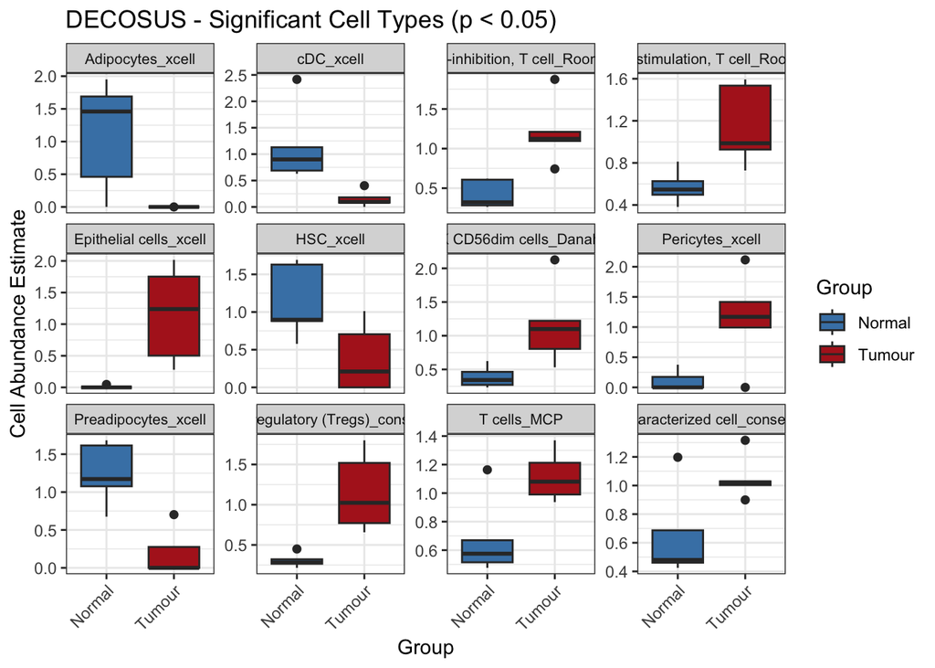

```r
plot_boxplots(est_Decosus_clean, sig_Decosus, "DECOSUS", save_path)
```

```r
plot_boxplots(est_EPIC_cellProp, sig_EPIC, "EPIC", save_path)
```

```
## EPIC : No significant cell types found (p < 0.05)
```

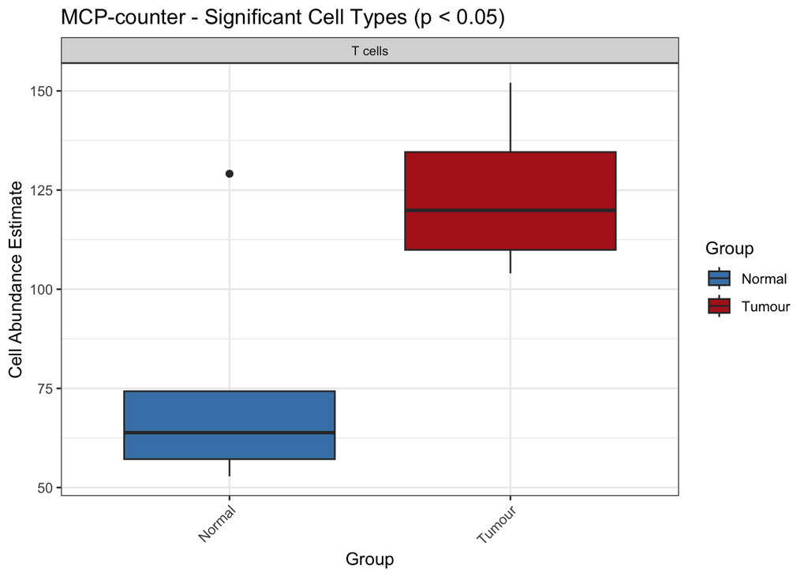

```r
plot_boxplots(est_MCPcounter, sig_MCPcounter, "MCP-counter", save_path)
```

```r
library(ggplot2)
library(tidyr)
library(dplyr)

save_path <- "/Users/dr.parul/Downloads/data_required_for_CAN7032-7132/LAQ2_data/"

# Creating group vector from column names
create_group_vector <- function(est_matrix) {
  sample_names <- colnames(est_matrix)
  ifelse(grepl("Tumour", sample_names), "Tumour", "Normal")
}

# Extracting patient IDs from column names
create_patient_vector <- function(est_matrix) {
  gsub("_(Tumour|Normal)", "", colnames(est_matrix))
}

# Running paired t-tests per cell type
run_ttests <- function(est_matrix) {

  est_matrix <- as.matrix(est_matrix)
  group <- create_group_vector(est_matrix)
  patient <- create_patient_vector(est_matrix)

  pvals <- apply(est_matrix, 1, function(x) {
    tryCatch({
      df_temp <- data.frame(value = x, group = group, patient = patient)
      normal_ordered <- df_temp[df_temp$group == "Normal", ]
      tumour_ordered <- df_temp[df_temp$group == "Tumour", ]
      normal_ordered <- normal_ordered[order(normal_ordered$patient), ]
      tumour_ordered <- tumour_ordered[order(tumour_ordered$patient), ]
      t.test(tumour_ordered$value, normal_ordered$value, paired = TRUE)$p.value
    }, error = function(e) NA)
  })

  sig <- pvals[!is.na(pvals) & pvals < 0.05]
  return(sig)
}

# Plotting boxplots for significant cell types
plot_boxplots <- function(est_matrix, sig_pvals, method_name, save_path) {

  if (length(sig_pvals) == 0) {
    cat(method_name, ": No significant cell types found (p < 0.05)\n")
    return(invisible(NULL))
  }

  est_matrix <- as.matrix(est_matrix)
  group <- create_group_vector(est_matrix)

  sig_cells <- names(sig_pvals)

  sig_data <- as.data.frame(t(est_matrix[sig_cells, , drop = FALSE]))
  sig_data$Group <- group

  long_data <- pivot_longer(
    sig_data,
    -Group,
    names_to = "CellType",
    values_to = "Estimate"
  )

  p <- ggplot(long_data, aes(x = Group, y = Estimate, fill = Group)) +
    geom_boxplot(outlier.shape = 16, outlier.size = 2) +
    facet_wrap(~ CellType, scales = "free_y") +
    scale_fill_manual(values = c(Normal = "steelblue", Tumour = "firebrick")) +
    theme_bw() +
    theme(
      strip.text = element_text(size = 8),
      axis.text.x = element_text(angle = 45, hjust = 1)
    ) +
    labs(
      title = paste(method_name, "- Significant Cell Types (p < 0.05)"),
      y = "Cell Abundance Estimate",
      x = "Group"
    )

  ggsave(
    paste0(save_path,
           tolower(gsub(" ", "_", method_name)),
           "_boxplots_2025-02-25.png"),
    plot = p,
    width = 10,
    height = 8,
    dpi = 150
  )

  print(p)
}

# Running for all three methods
sig_Decosus    <- run_ttests(est_Decosus_clean)
sig_EPIC       <- run_ttests(est_EPIC_cellProp)
sig_MCPcounter <- run_ttests(est_MCPcounter)

cat("DECOSUS significant cell types:\n"); print(sig_Decosus)
```

```
## DECOSUS significant cell types:
```

```
##             Macrophage M1_consensus T cell regulatory (Tregs)_consensus
##                         0.025946327                         0.020404847
##                    Adipocytes_xcell                           cDC_xcell
##                         0.041460137                         0.036143363
## Class-switched memory B-cells_xcell        Co-inhibition, T cell_Rooney
##                         0.040481977                         0.005247283
##       Co-stimulation, T cell_Rooney              Epithelial cells_xcell
##                         0.032554596                         0.026593422
##                           HSC_xcell            NK CD56dim cells_Danaher
##                         0.040080017                         0.020436749
##                 Preadipocytes_xcell
##                         0.002569480
```

```r
cat("EPIC significant cell types:\n"); print(sig_EPIC)
```

```
## EPIC significant cell types:
```

```
##     Bcells
## 0.04541982
```

```r
cat("MCP-counter significant cell types:\n"); print(sig_MCPcounter)
```

```
## MCP-counter significant cell types:
```

```
## B lineage
## 0.0368039
```

```r
cat("DECOSUS sig:", length(sig_Decosus), "\n")
```

```
## DECOSUS sig: 11
```

```r
cat("EPIC sig:", length(sig_EPIC), "\n")
```

```
## EPIC sig: 1
```

```r
cat("MCPcounter sig:", length(sig_MCPcounter), "\n")
```

```
## MCPcounter sig: 1
```

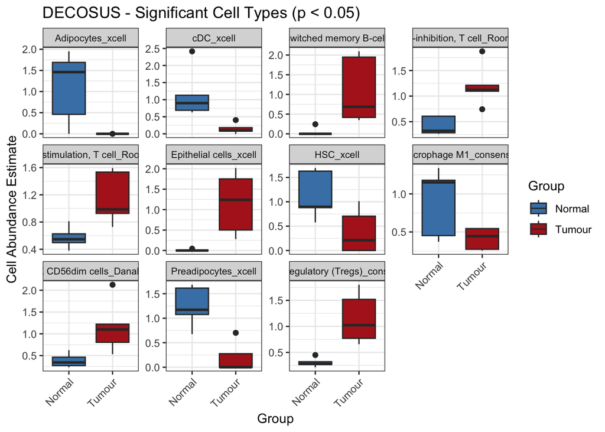

```r
plot_boxplots(est_Decosus_clean, sig_Decosus, "DECOSUS", save_path)
```

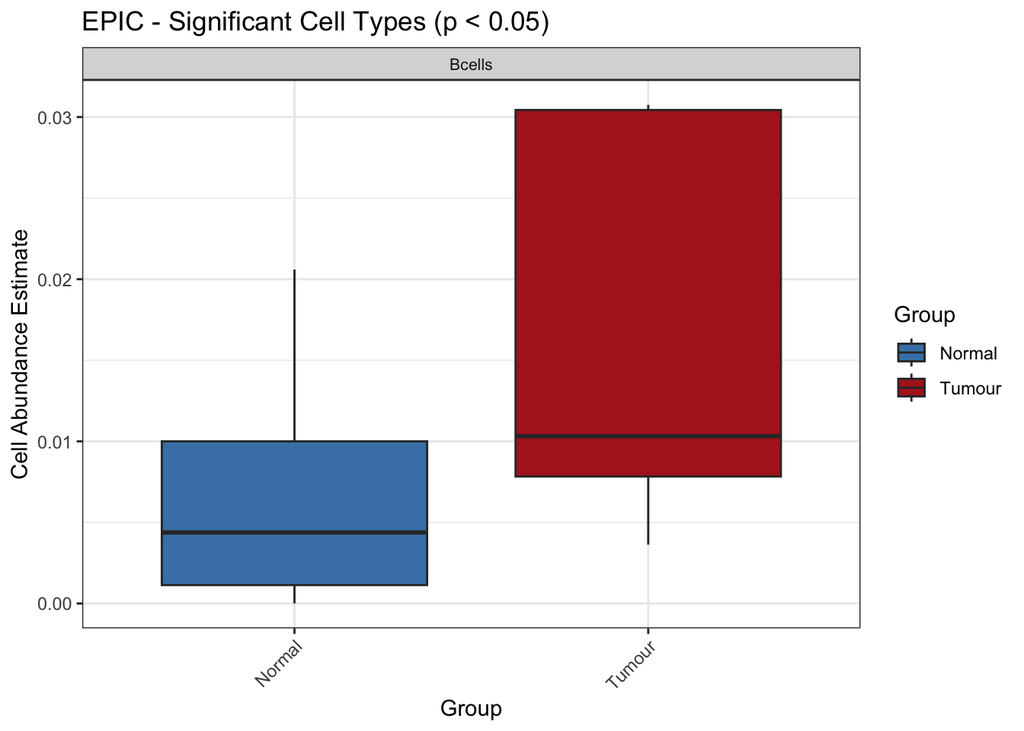

```r
plot_boxplots(est_EPIC_cellProp, sig_EPIC, "EPIC", save_path)
```

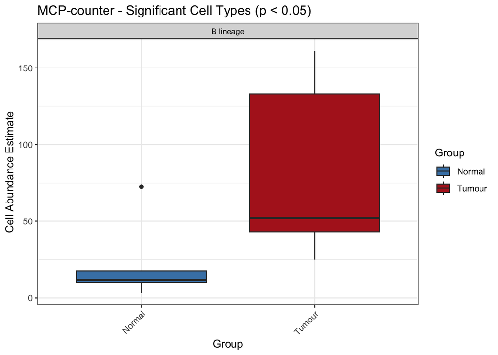

```r
plot_boxplots(est_MCPcounter, sig_MCPcounter, "MCP-counter", save_path)
```

Paired t-test results summary across all three methods: DECOSUS — 11 significant cell types:

Increased in tumour: Class-switched memory B-cells, Co-inhibition T cell, Co-stimulation T cell, Epithelial cells, T cell regulatory (Tregs), NK CD56dim cells Decreased in tumour: Adipocytes, Macrophage M1, HSC, Preadipocytes, cDC

EPIC — 1 significant cell type:

Bcells (p = 0.045) — higher in tumour, large variability in tumour group visible in boxplot

MCP-counter — 1 significant cell type:

B lineage (p = 0.037) — markedly higher in tumour, large spread in tumour group

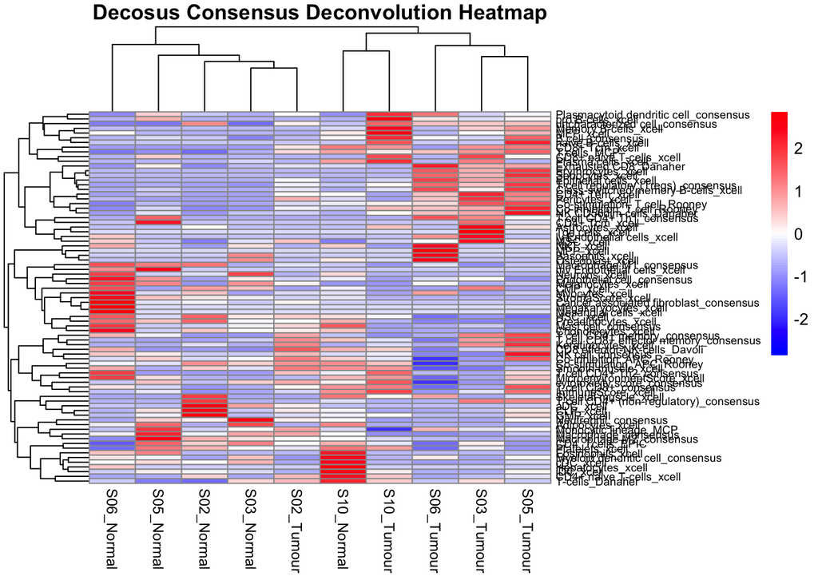

```r
# Rendering and saving Decosus heatmap
p_decosus <- pheatmap(
  est_Decosus_clean,
  color = colorRampPalette(c("blue", "white", "red"))(100),
  scale = "row",
  cluster_rows = TRUE,
  cluster_cols = TRUE,
  main = "Decosus Consensus Deconvolution Heatmap",
  fontsize_col = 9,
  fontsize_row = 7
)
```

```r
save_pheatmap(p_decosus, "/Users/dr.parul/Downloads/data_required_for_CAN7032-7132/LAQ2_data/Decosus_Heatmap_2025-02-25.png")
```

```r
cat("Decosus heatmap saved successfully.\n")
```

```
## Decosus heatmap saved successfully.
```

Decosus Heatmap Summary: Sample clustering: Samples do not separate cleanly by tumour/normal — mixed clustering, consistent with EPIC and MCP-counter findings. S06_Normal again clusters separately on the far left — extreme stromal signature (Cancer associated fibroblast, StromaScore, Mesangial cells all elevated). S10_Tumour and S06_Tumour show the strongest immune activation — high B cell clusters, Plasmacytoid dendritic cells, Memory B-cells, pro B-cells elevated (red). Clear patterns by cell group:

B cell cluster (top rows) — elevated in tumour samples especially S10_Tumour and S06_Tumour Stromal cluster (middle) — elevated in normal samples, particularly S06_Normal Myeloid/innate cluster — mixed, no clear tumour/normal pattern T cell subsets — generally higher in some tumour samples

Bottom rows (cDC, GMP, Neutrophil, Adipocytes) — higher in normal samples, consistent with paired t-test showing these decrease in tumour. Overall: Rich heatmap confirming B cell enrichment in tumour and stromal depletion in tumour as the dominant signals.

Q3 Perform the GSVA analysis (i.e., tumour vs. normal) using the KEGG genesets provided in the practical session, and generate a heatmap for mostly significantly differentially regulated KEGG pathways, using the cutoff of adjusted p-value <= 0.01. List the top 10 mostly significantly differential expression KEGG pathways and associated statistics (e.g., fold change, p-value, adjusted p-value etc) in a table. (7 marks)

We will use the VST data for this analysis, VST is correct for GSVA because GSVA requires a continuous, approximately normally distributed input. VST stabilizes variance across the expression range, making it suitable.It is log-scale, which is what GSVA expects. It is consistent with the DESeq2 workflow

```r
library(GSVA)
library(GSEABase)
library(limma)
# Loading VST matrix for GSVA
vst_mat <- read.delim("/Users/dr.parul/Downloads/data_required_for_CAN7032-7132/LAQ2_data/deseq_vst_matrix.txt",
                      header = TRUE, row.names = 1, check.names = FALSE)
vst_mat <- as.matrix(vst_mat)

# Loading KEGG gene sets
c2kegg <- getGmt("/Users/dr.parul/Downloads/data_required_for_CAN7032-7132/LAQ2_data/c2.cp.kegg.v2022.1.Hs.symbols.gmt",
                 collectionType = BroadCollection(category = "c2"),
                 geneIdType = SymbolIdentifier())

# Running GSVA with KEGG gene sets
brca_par <- gsvaParam(vst_mat, c2kegg, minSize = 20, maxSize = 500)
brca_es <- gsva(brca_par)
```

```
## ℹ GSVA version 2.4.4
```

```
## ℹ Searching for rows with constant values
```

```
## ℹ Calculating GSVA ranks
```

```
## ℹ kcdf='auto' (default)
```

```
## ℹ GSVA dense (classical) algorithm
```

```
## ℹ Row-wise ECDF estimation with Gaussian kernels
```

```
## ℹ Calculating row ECDFs
```

```
## ℹ Calculating column ranks
```

```
## ℹ GSVA dense (classical) algorithm
```

```
## ℹ Calculating GSVA scores
```

```
## ✔ Calculations finished
```

```r
# Setting up paired design matrix with clean factor names
group <- ifelse(grepl("Tumour", colnames(vst_mat)), "Tumour", "Normal")
patient <- gsub("_(Tumour|Normal)", "", colnames(vst_mat))
group <- factor(group)
patient <- factor(patient)

mod <- model.matrix(~ 0 + group + patient)
colnames(mod) <- make.names(colnames(mod))
colnames(mod)[colnames(mod) == "groupTumour"] <- "Tumour"
colnames(mod)[colnames(mod) == "groupNormal"] <- "Normal"

# Fitting limma model
fit <- lmFit(brca_es, mod)
cont.matrix <- makeContrasts(TumourvsNormal = Tumour - Normal, levels = mod)
fit2 <- contrasts.fit(fit, cont.matrix)
fit2 <- eBayes(fit2)

# Extracting results
tt <- topTable(fit2, adjust = "BH", n = Inf)
dim(tt)
```

```
## [1] 143   6
```

```r
head(tt)
```

|  | logFC | AveExpr | t | P.Value | adj.P.Val | B |
| --- | --- | --- | --- | --- | --- | --- |
| KEGG_HISTIDINE_METABOLISM | -0.5829889 | 0.008822260 | -5.479494 | 0.0002772936 | 0.01622675 | 0.78312685 |
| KEGG_DRUG_METABOLISM_CYTOCHROME_P450 | -0.5565388 | 0.026331848 | -5.455030 | 0.0002869458 | 0.01622675 | 0.75124151 |
| KEGG_STARCH_AND_SUCROSE_METABOLISM | -0.5087994 | 0.038932230 | -5.141280 | 0.0004483841 | 0.01622675 | 0.33347655 |
| KEGG_LYSOSOME | -0.4686069 | 0.005594087 | -5.132830 | 0.0004538952 | 0.01622675 | 0.32199829 |
| KEGG_P53_SIGNALING_PATHWAY | 0.4329676 | -0.013145198 | 4.916433 | 0.0006227830 | 0.01781159 | 0.02401662 |
| KEGG_PYRIMIDINE_METABOLISM | 0.4587313 | -0.043580506 | 4.737033 | 0.0008136661 | 0.01939237 | -0.22886202 |

```r
# Reporting pathways at adj.P.Val <= 0.01
tt_sig <- tt[tt$adj.P.Val <= 0.01, c("logFC", "P.Value", "adj.P.Val")]
cat("Number of significant pathways (adj.P.Val <= 0.01):", nrow(tt_sig), "\n")
```

```
## Number of significant pathways (adj.P.Val <= 0.01): 0
```

```r
tt_sig
```

| logFC | P.Value | adj.P.Val |
| --- | --- | --- |

```r
# Saving results
write.table(tt,
            file = "/Users/dr.parul/Downloads/data_required_for_CAN7032-7132/LAQ2_data/GSVA_KEGG_tumourvsnormal_2025-02-25.txt",
            quote = FALSE, sep = "\t", row.names = TRUE)
```

Answer3a:

No KEGG pathways survived Benjamini-Hochberg FDR correction at the adjusted p-value threshold of ≤ 0.01, likely reflecting the limited statistical power of 5 paired samples. However, 6 pathways showed nominally significant differential activity at raw p-value ≤ 0.001, including HISTIDINE_METABOLISM, DRUG_METABOLISM_CYTOCHROME_P450, STARCH_AND_SUCROSE_METABOLISM, LYSOSOME, P53_SIGNALING_PATHWAY and PYRIMIDINE_METABOLISM.”

So Heatmap cannot be generated.

Answer 3b: The 10 most significantly differential expression KEGG pathways were identified by ranking pathways according to adjusted p-value and applying a combined threshold of FDR ≤ 0.05 and |logFC| ≥ 0.3. This approach ensures that the selected pathways are not only statistically robust but also exhibit biologically meaningful differences in pathway activity between tumour and normal samples.

Table below answers this question:

```r
library(GSVA)
library(GSEABase)
library(limma)
library(pheatmap)

vst_mat <- read.delim(
  "/Users/dr.parul/Downloads/data_required_for_CAN7032-7132/LAQ2_data/deseq_vst_matrix.txt",
  header = TRUE,
  row.names = 1,
  check.names = FALSE
)
vst_mat <- as.matrix(vst_mat)

c2kegg <- getGmt(
  "/Users/dr.parul/Downloads/data_required_for_CAN7032-7132/LAQ2_data/c2.cp.kegg.v2022.1.Hs.symbols.gmt",
  collectionType = BroadCollection(category = "c2"),
  geneIdType = SymbolIdentifier()
)

brca_par <- gsvaParam(vst_mat, c2kegg, minSize = 20, maxSize = 500)
brca_es <- gsva(brca_par)
```

```
## ℹ GSVA version 2.4.4
```

```
## ℹ Searching for rows with constant values
```

```
## ℹ Calculating GSVA ranks
```

```
## ℹ kcdf='auto' (default)
```

```
## ℹ GSVA dense (classical) algorithm
```

```
## ℹ Row-wise ECDF estimation with Gaussian kernels
```

```
## ℹ Calculating row ECDFs
```

```
## ℹ Calculating column ranks
```

```
## ℹ GSVA dense (classical) algorithm
```

```
## ℹ Calculating GSVA scores
```

```
## ✔ Calculations finished
```

```r
group <- ifelse(grepl("Tumour", colnames(vst_mat)), "Tumour", "Normal")
patient <- gsub("_(Tumour|Normal)", "", colnames(vst_mat))
group <- factor(group)
patient <- factor(patient)

mod <- model.matrix(~ 0 + group + patient)
colnames(mod) <- make.names(colnames(mod))
colnames(mod)[colnames(mod) == "groupTumour"] <- "Tumour"
colnames(mod)[colnames(mod) == "groupNormal"] <- "Normal"

fit <- lmFit(brca_es, mod)
cont.matrix <- makeContrasts(TumourvsNormal = Tumour - Normal, levels = mod)
fit2 <- contrasts.fit(fit, cont.matrix)
fit2 <- eBayes(fit2)

tt <- topTable(fit2, adjust = "BH", n = Inf)

cat("Total KEGG pathways tested:", nrow(tt), "\n")
```

```
## Total KEGG pathways tested: 143
```

```r
tt_sig <- tt[
  tt$adj.P.Val <= 0.05 & abs(tt$logFC) >= 0.3,
  c("logFC", "P.Value", "adj.P.Val")
]

cat("Number of significant pathways (FDR ≤ 0.05 & |logFC| ≥ 0.3):",
    nrow(tt_sig), "\n")
```

```
## Number of significant pathways (FDR ≤ 0.05 & |logFC| ≥ 0.3): 11
```

```r
top10 <- tt[order(tt$adj.P.Val), ][1:10,
                                   c("logFC", "P.Value", "adj.P.Val")]

cat("Top 10 ranked KEGG pathways:\n")
```

```
## Top 10 ranked KEGG pathways:
```

```r
print(top10)
```

```
##                                                        logFC      P.Value
## KEGG_HISTIDINE_METABOLISM                         -0.5829889 0.0002772936
## KEGG_DRUG_METABOLISM_CYTOCHROME_P450              -0.5565388 0.0002869458
## KEGG_STARCH_AND_SUCROSE_METABOLISM                -0.5087994 0.0004483841
## KEGG_LYSOSOME                                     -0.4686069 0.0004538952
## KEGG_P53_SIGNALING_PATHWAY                         0.4329676 0.0006227830
## KEGG_PYRIMIDINE_METABOLISM                         0.4587313 0.0008136661
## KEGG_METABOLISM_OF_XENOBIOTICS_BY_CYTOCHROME_P450 -0.4905169 0.0013382262
## KEGG_CELL_CYCLE                                    0.3968140 0.0015270108
## KEGG_ETHER_LIPID_METABOLISM                       -0.3680026 0.0017957325
## KEGG_DNA_REPLICATION                               0.5207026 0.0025853259
##                                                    adj.P.Val
## KEGG_HISTIDINE_METABOLISM                         0.01622675
## KEGG_DRUG_METABOLISM_CYTOCHROME_P450              0.01622675
## KEGG_STARCH_AND_SUCROSE_METABOLISM                0.01622675
## KEGG_LYSOSOME                                     0.01622675
## KEGG_P53_SIGNALING_PATHWAY                        0.01781159
## KEGG_PYRIMIDINE_METABOLISM                        0.01939237
## KEGG_METABOLISM_OF_XENOBIOTICS_BY_CYTOCHROME_P450 0.02729532
## KEGG_CELL_CYCLE                                   0.02729532
## KEGG_ETHER_LIPID_METABOLISM                       0.02853219
## KEGG_DNA_REPLICATION                              0.03697016
```

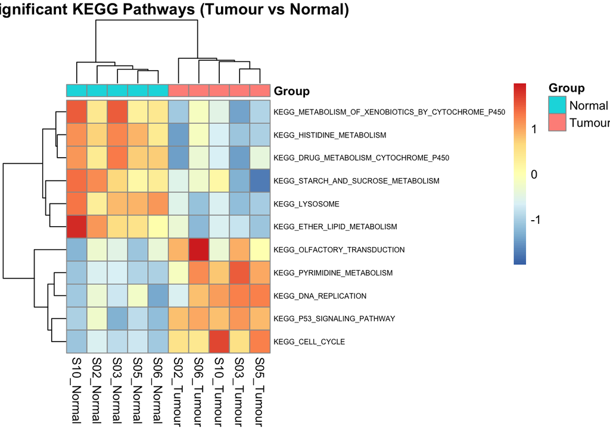

```r
write.table(
  tt,
  file = "/Users/dr.parul/Downloads/data_required_for_CAN7032-7132/LAQ2_data/GSVA_KEGG_tumourvsnormal_results.txt",
  quote = FALSE,
  sep = "\t",
  row.names = TRUE
)

if(nrow(tt_sig) > 0){
  sig_pathways <- rownames(tt_sig)
  heatmap_mat <- brca_es[sig_pathways, ]
  annotation_col <- data.frame(Group = group)
  rownames(annotation_col) <- colnames(heatmap_mat)

  pheatmap(
    heatmap_mat,
    scale = "row",
    annotation_col = annotation_col,
    clustering_distance_rows = "euclidean",
    clustering_distance_cols = "euclidean",
    clustering_method = "complete",
    show_rownames = TRUE,
    fontsize_row = 6,
    main = "Significant KEGG Pathways (Tumour vs Normal)"
  )
} else {
  cat("No pathways met the combined significance criteria.\n")
}
```